# Segmentación de clientes

Joel Ramirez

2025

### Planteamiento del problema

El objetivo principal es segmentar la base de clientes para entender cómo factores como ingresos, estado civil y aceptación de promociones influyen en el gasto y la fidelización. Además, se pretende identificar qué canales de compra (web, catálogo, tienda física) y qué tipos de promociones generan mayor impacto en las ventas y en la respuesta de los clientes.

Para ello, se realizará un análisis integral que incluye:

- Limpieza y preparación de datos, incluyendo manejo de valores faltantes.
- Creación de variables relevantes como gasto total y antigüedad del cliente.
- Análisis descriptivo para explorar la influencia de variables clave en el comportamiento de compra.
- Aplicación de Análisis de Componentes Principales (PCA) para reducir la dimensionalidad y facilitar la segmentación.
- Uso de clustering (k-means) para identificar grupos de clientes con características similares.
- Perfilado de clusters para interpretar las diferencias y diseñar estrategias de marketing específicas.

Este enfoque permitirá a la empresa tomar decisiones informadas para mejorar la efectividad de sus campañas y aumentar la satisfacción y lealtad de sus clientes

#### Carga de datos

```r
library(janitor)
library(dplyr)
```

```r
library(naniar)
library(ggplot2)
library(tidyr)

df <- read.delim("C:/Users/User/OneDrive/Desktop/Segmentacion de clientes/marketing_campaign.csv", sep="\t", header=TRUE)

head(df)
```

```
##     ID Year_Birth  Education Marital_Status Income Kidhome Teenhome Dt_Customer
## 1 5524       1957 Graduation         Single  58138       0        0  04-09-2012
## 2 2174       1954 Graduation         Single  46344       1        1  08-03-2014
## 3 4141       1965 Graduation       Together  71613       0        0  21-08-2013
## 4 6182       1984 Graduation       Together  26646       1        0  10-02-2014
## 5 5324       1981        PhD        Married  58293       1        0  19-01-2014
## 6 7446       1967     Master       Together  62513       0        1  09-09-2013
##   Recency MntWines MntFruits MntMeatProducts MntFishProducts MntSweetProducts
## 1      58      635        88             546             172               88
## 2      38       11         1               6               2                1
## 3      26      426        49             127             111               21
## 4      26       11         4              20              10                3
## 5      94      173        43             118              46               27
## 6      16      520        42              98               0               42
##   MntGoldProds NumDealsPurchases NumWebPurchases NumCatalogPurchases
```

[output cut: 20 more lines]

**Interpretación**

**ID:** Identificador único para cada cliente.

**Year_Birth:** Año de nacimiento del cliente.

**Education:** Nivel educativo alcanzado por el cliente (por ejemplo, Graduation, PhD, Master).

**Marital_Status:** Estado civil del cliente (Single, Married, Together, etc.).

**Income:** Ingreso anual del cliente en moneda local.

**Kidhome:** Número de hijos pequeños en el hogar.

**Teenhome:** Número de adolescentes en el hogar.

**Dt_Customer:** Fecha en que el cliente se registró o se convirtió en cliente (formato día-mes-año).

**Recency:** Número de días desde la última compra del cliente.

**MntWines:** Monto gastado en vinos.

**MntFruits:** Monto gastado en frutas.

**MntMeatProducts:** Monto gastado en productos cárnicos.

**MntFishProducts:** Monto gastado en productos de pescado.

**MntSweetProducts:** Monto gastado en productos dulces.

**MntGoldProds:** Monto gastado en productos de oro.

**NumDealsPurchases:** Número de compras realizadas con ofertas o descuentos.

**NumWebPurchases:** Número de compras realizadas a través de la web.

**NumCatalogPurchases:** Número de compras realizadas a través de catálogos.

**NumStorePurchases:** Número de compras realizadas en tienda física.

**NumWebVisitsMonth:** Número de visitas al sitio web en el último mes.

**AcceptedCmp3, AcceptedCmp4, AcceptedCmp5, AcceptedCmp1, AcceptedCmp2:** Indicadores binarios (0 o 1) que muestran si el cliente aceptó campañas de marketing específicas (por ejemplo, campañas 1 a 5).

**Complain:** Indicador binario que muestra si el cliente ha presentado alguna queja.

**Z_CostContact:** Costo asociado al contacto con el cliente (probablemente en alguna unidad monetaria o puntos).

**Z_Revenue:** Ingreso generado por el cliente (posiblemente en alguna unidad monetaria o puntos).

**Response:** Indicador binario que muestra si el cliente respondió a una campaña de marketing (1 = sí, 0 = no).

#### Preparación de los datos

Adecuar nombres de columnas

```r
df <- clean_names(df)
```

Tamaño del dataset:

```r
dim(df)
```

```
## [1] 2240   29
```

Validamos cada tipo de variable:

```r
str(df)
```

```
## 'data.frame':    2240 obs. of  29 variables:
##  $ id                   : int  5524 2174 4141 6182 5324 7446 965 6177 4855 5899 ...
##  $ year_birth           : int  1957 1954 1965 1984 1981 1967 1971 1985 1974 1950 ...
##  $ education            : chr  "Graduation" "Graduation" "Graduation" "Graduation" ...
##  $ marital_status       : chr  "Single" "Single" "Together" "Together" ...
##  $ income               : int  58138 46344 71613 26646 58293 62513 55635 33454 30351 5648 ...
##  $ kidhome              : int  0 1 0 1 1 0 0 1 1 1 ...
##  $ teenhome             : int  0 1 0 0 0 1 1 0 0 1 ...
##  $ dt_customer          : chr  "04-09-2012" "08-03-2014" "21-08-2013" "10-02-2014" ...
##  $ recency              : int  58 38 26 26 94 16 34 32 19 68 ...
##  $ mnt_wines            : int  635 11 426 11 173 520 235 76 14 28 ...
##  $ mnt_fruits           : int  88 1 49 4 43 42 65 10 0 0 ...
##  $ mnt_meat_products    : int  546 6 127 20 118 98 164 56 24 6 ...
##  $ mnt_fish_products    : int  172 2 111 10 46 0 50 3 3 1 ...
##  $ mnt_sweet_products   : int  88 1 21 3 27 42 49 1 3 1 ...
##  $ mnt_gold_prods       : int  88 6 42 5 15 14 27 23 2 13 ...
##  $ num_deals_purchases  : int  3 2 1 2 5 2 4 2 1 1 ...
##  $ num_web_purchases    : int  8 1 8 2 5 6 7 4 3 1 ...
##  $ num_catalog_purchases: int  10 1 2 0 3 4 3 0 0 0 ...
##  $ num_store_purchases  : int  4 2 10 4 6 10 7 4 2 0 ...
##  $ num_web_visits_month : int  7 5 4 6 5 6 6 8 9 20 ...
##  $ accepted_cmp3        : int  0 0 0 0 0 0 0 0 0 1 ...
##  $ accepted_cmp4        : int  0 0 0 0 0 0 0 0 0 0 ...
##  $ accepted_cmp5        : int  0 0 0 0 0 0 0 0 0 0 ...
##  $ accepted_cmp1        : int  0 0 0 0 0 0 0 0 0 0 ...
##  $ accepted_cmp2        : int  0 0 0 0 0 0 0 0 0 0 ...
##  $ complain             : int  0 0 0 0 0 0 0 0 0 0 ...
##  $ z_cost_contact       : int  3 3 3 3 3 3 3 3 3 3 ...
##  $ z_revenue            : int  11 11 11 11 11 11 11 11 11 11 ...
##  $ response             : int  1 0 0 0 0 0 0 0 1 0 ...
```

Verificamos estadisticamente cada variable:

```r
summary(df)
```

```
##        id          year_birth    education         marital_status
##  Min.   :    0   Min.   :1893   Length:2240        Length:2240
##  1st Qu.: 2828   1st Qu.:1959   Class :character   Class :character
##  Median : 5458   Median :1970   Mode  :character   Mode  :character
##  Mean   : 5592   Mean   :1969
##  3rd Qu.: 8428   3rd Qu.:1977
##  Max.   :11191   Max.   :1996
##
##      income          kidhome          teenhome      dt_customer
##  Min.   :  1730   Min.   :0.0000   Min.   :0.0000   Length:2240
##  1st Qu.: 35303   1st Qu.:0.0000   1st Qu.:0.0000   Class :character
##  Median : 51382   Median :0.0000   Median :0.0000   Mode  :character
##  Mean   : 52247   Mean   :0.4442   Mean   :0.5062
##  3rd Qu.: 68522   3rd Qu.:1.0000   3rd Qu.:1.0000
##  Max.   :666666   Max.   :2.0000   Max.   :2.0000
##  NA's   :24
##     recency        mnt_wines         mnt_fruits    mnt_meat_products
##  Min.   : 0.00   Min.   :   0.00   Min.   :  0.0   Min.   :   0.0
##  1st Qu.:24.00   1st Qu.:  23.75   1st Qu.:  1.0   1st Qu.:  16.0
##  Median :49.00   Median : 173.50   Median :  8.0   Median :  67.0
##  Mean   :49.11   Mean   : 303.94   Mean   : 26.3   Mean   : 166.9
##  3rd Qu.:74.00   3rd Qu.: 504.25   3rd Qu.: 33.0   3rd Qu.: 232.0
##  Max.   :99.00   Max.   :1493.00   Max.   :199.0   Max.   :1725.0
##
##  mnt_fish_products mnt_sweet_products mnt_gold_prods   num_deals_purchases
##  Min.   :  0.00    Min.   :  0.00     Min.   :  0.00   Min.   : 0.000
##  1st Qu.:  3.00    1st Qu.:  1.00     1st Qu.:  9.00   1st Qu.: 1.000
##  Median : 12.00    Median :  8.00     Median : 24.00   Median : 2.000
##  Mean   : 37.53    Mean   : 27.06     Mean   : 44.02   Mean   : 2.325
##  3rd Qu.: 50.00    3rd Qu.: 33.00     3rd Qu.: 56.00   3rd Qu.: 3.000
##  Max.   :259.00    Max.   :263.00     Max.   :362.00   Max.   :15.000
##
##  num_web_purchases num_catalog_purchases num_store_purchases
##  Min.   : 0.000    Min.   : 0.000        Min.   : 0.00
##  1st Qu.: 2.000    1st Qu.: 0.000        1st Qu.: 3.00
##  Median : 4.000    Median : 2.000        Median : 5.00
##  Mean   : 4.085    Mean   : 2.662        Mean   : 5.79
##  3rd Qu.: 6.000    3rd Qu.: 4.000        3rd Qu.: 8.00
##  Max.   :27.000    Max.   :28.000        Max.   :13.00
##
```

[output cut: 9 more lines]

```
##  Min.   :0.00000   Min.   :0.00000   Min.   :0.000000   Min.   :3
##  1st Qu.:0.00000   1st Qu.:0.00000   1st Qu.:0.000000   1st Qu.:3
##  Median :0.00000   Median :0.00000   Median :0.000000   Median :3
##  Mean   :0.06429   Mean   :0.01339   Mean   :0.009375   Mean   :3
##  3rd Qu.:0.00000   3rd Qu.:0.00000   3rd Qu.:0.000000   3rd Qu.:3
##  Max.   :1.00000   Max.   :1.00000   Max.   :1.000000   Max.   :3
##
##    z_revenue     response
##  Min.   :11   Min.   :0.0000
##  1st Qu.:11   1st Qu.:0.0000
##  Median :11   Median :0.0000
##  Mean   :11   Mean   :0.1491
##  3rd Qu.:11   3rd Qu.:0.0000
##  Max.   :11   Max.   :1.0000
##
```

Visualizar valores faltantes

```r
summary_na <- df %>% summarise_all(~sum(is.na(.)))
print(summary_na)
```

```
##   id year_birth education marital_status income kidhome teenhome dt_customer
## 1  0          0         0              0     24       0        0           0
##   recency mnt_wines mnt_fruits mnt_meat_products mnt_fish_products
## 1       0         0          0                 0                 0
##   mnt_sweet_products mnt_gold_prods num_deals_purchases num_web_purchases
## 1                  0              0                   0                 0
##   num_catalog_purchases num_store_purchases num_web_visits_month accepted_cmp3
## 1                     0                   0                    0             0
##   accepted_cmp4 accepted_cmp5 accepted_cmp1 accepted_cmp2 complain
## 1             0             0             0             0        0
##   z_cost_contact z_revenue response
## 1              0         0        0
```

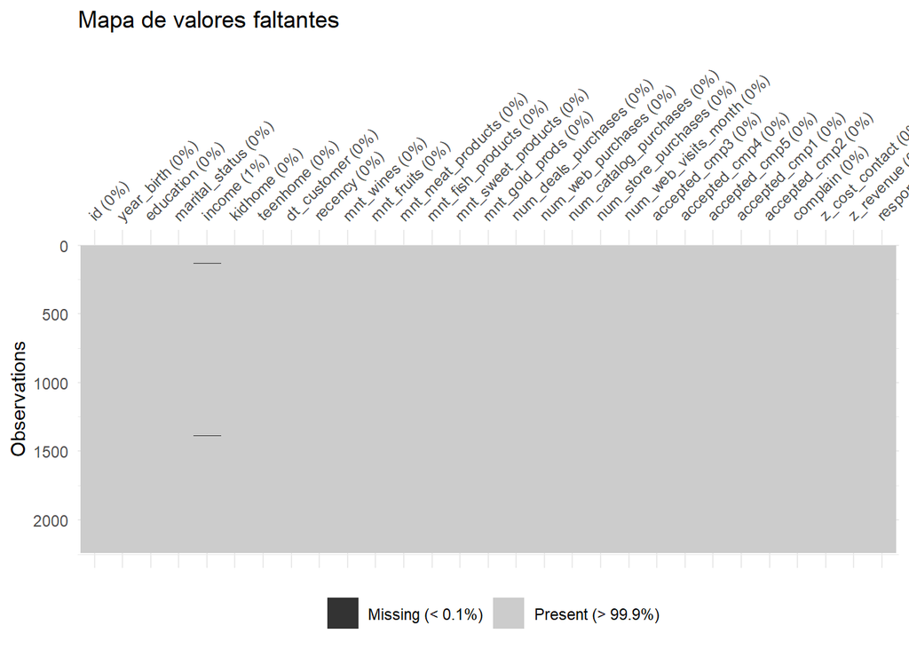

```r
naniar::vis_miss(df, warn_large_data = FALSE) + ggtitle("Mapa de valores faltantes")
```

```r
missing_pct <- df %>% summarise_all(~mean(is.na(.))*100) %>%
  gather(key = "variable", value = "pct_missing")
```

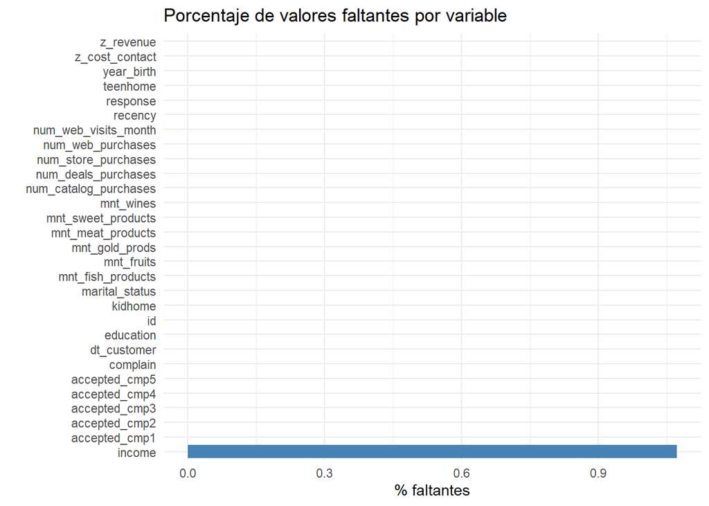

```r
ggplot(missing_pct, aes(x = reorder(variable, -pct_missing), y = pct_missing)) +
  geom_bar(stat = "identity", fill = "steelblue") +
  coord_flip() +
  labs(title = "Porcentaje de valores faltantes por variable", y = "% faltantes", x = "") +
  theme_minimal()
```

Imputamos los valores NA en income con su media:

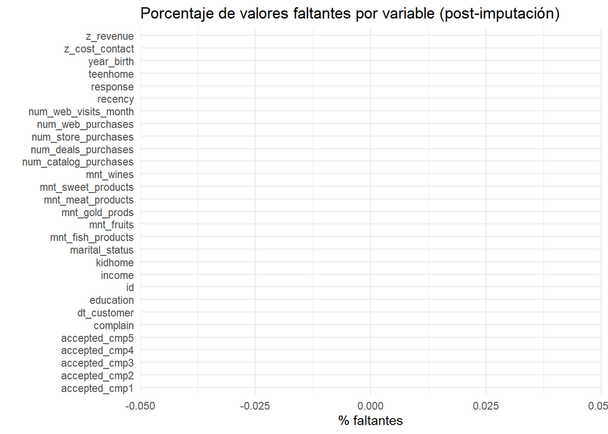

```r
mean_income <- mean(df$income, na.rm = TRUE)
df$income[is.na(df$income)] <- mean_income

# Confirmar imputación
missing_pct <- df %>% summarise_all(~mean(is.na(.))*100) %>%
  gather(key = "variable", value = "pct_missing")

ggplot(missing_pct, aes(x = reorder(variable, -pct_missing), y = pct_missing)) +
  geom_bar(stat = "identity", fill = "steelblue") +
  coord_flip() +
  labs(title = "Porcentaje de valores faltantes por variable (post-imputación)", y = "% faltantes", x = "") +
  theme_minimal()
```

#### Exploramos y analizamos el dataset

Vemos cómo influyen factores como ingresos o estado civil en el gasto.

```r
# Crear una nueva columna con el gasto total sumando las categorías de gasto
df$gasto_total <- df$mnt_wines + df$mnt_fruits + df$mnt_meat_products +
  df$mnt_fish_products + df$mnt_sweet_products + df$mnt_gold_prods

# Crear una variable categórica para rangos de ingreso (bajo, medio, alto)
df$ingreso_cat <- cut(df$income,
                      breaks = quantile(df$income, probs = c(0, 0.33, 0.66, 1)),
                      labels = c("Bajo", "Medio", "Alto"), include.lowest = TRUE)

# Calcular gasto promedio por estado civil
gasto_por_estado <- aggregate(gasto_total ~ marital_status, data = df, FUN = mean)

# Calcular gasto promedio por categoría de ingreso
gasto_por_ingreso <- aggregate(gasto_total ~ ingreso_cat, data = df, FUN = mean)

# Mostrar resultados
print("Gasto promedio por estado civil:")
```

```
## [1] "Gasto promedio por estado civil:"
```

```r
print(gasto_por_estado)
```

```
##   marital_status gasto_total
## 1         Absurd   1192.5000
## 2          Alone    256.6667
## 3       Divorced    610.6293
## 4        Married    590.8021
## 5         Single    606.4833
## 6       Together    608.3879
## 7          Widow    738.8182
## 8           YOLO    424.0000
```

```r
print("Gasto promedio por categoría de ingreso:")
```

```
## [1] "Gasto promedio por categoría de ingreso:"
```

```r
print(gasto_por_ingreso)
```

```
##   ingreso_cat gasto_total
## 1        Bajo    94.85521
## 2       Medio   447.05819
## 3        Alto  1255.26772
```

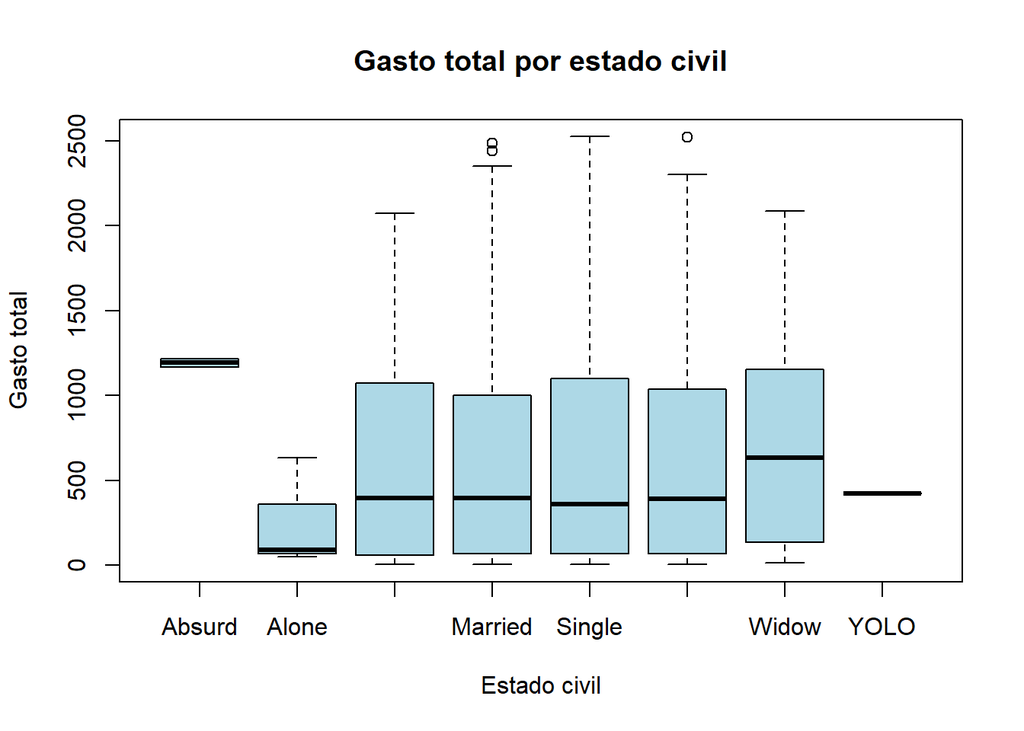

```r
boxplot(gasto_total ~ marital_status, data = df, main = "Gasto total por estado civil",
        ylab = "Gasto total", xlab = "Estado civil", col = "lightblue")
```

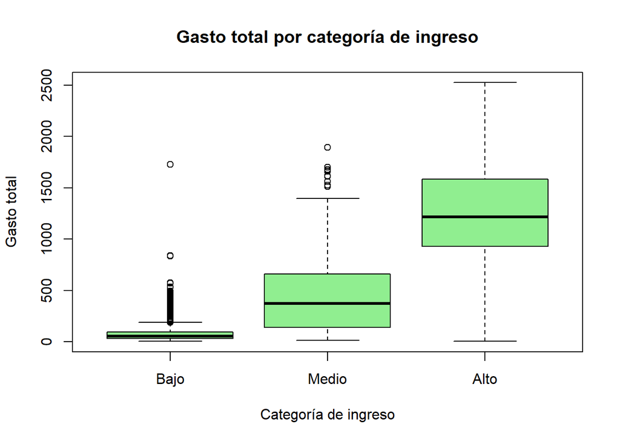

```r
boxplot(gasto_total ~ ingreso_cat, data = df, main = "Gasto total por categoría de ingreso",
        ylab = "Gasto total", xlab = "Categoría de ingreso", col = "lightgreen")
```

##### Analizamos qué promociones o canales (web, catálogo, tienda) generan más compras o fidelización:

canal en que los clientes compran más en promedio:

```r
promedio_compras <- colMeans(df[, c("num_web_purchases", "num_catalog_purchases", "num_store_purchases")])
print(promedio_compras)
```

```
##     num_web_purchases num_catalog_purchases   num_store_purchases
##              4.084821              2.662054              5.790179
```

Promociones que generan más compras o fidelización

```r
library(dplyr)

df %>%
  summarise(
    tasa_cmp1 = mean(response[accepted_cmp1 == 1]),
    tasa_cmp2 = mean(response[accepted_cmp2 == 1]),
    tasa_cmp3 = mean(response[accepted_cmp3 == 1]),
    tasa_cmp4 = mean(response[accepted_cmp4 == 1]),
    tasa_cmp5 = mean(response[accepted_cmp5 == 1])
  )
```

```
##   tasa_cmp1 tasa_cmp2 tasa_cmp3 tasa_cmp4 tasa_cmp5
## 1 0.5486111 0.6666667 0.4723926 0.3712575 0.5644172
```

#### Preparamos para escalar las variables y aplicar Kmeans

Convertir dt_customer a Date y crear variable antigüedad en días

```r
df$dt_customer <- as.Date(df$dt_customer, format = "%d-%m-%Y")
max_date <- max(df$dt_customer, na.rm = TRUE)
df$customer_age_days <- as.numeric(max_date - df$dt_customer)

# Codificar variables categóricas con dummies
df$education <- as.factor(df$education)
df$marital_status <- as.factor(df$marital_status)

dummies <- model.matrix(~ education + marital_status - 1, data = df)

df_prepared <- cbind(df %>% select(-education, -marital_status), dummies)

# Excluir columnas no numéricas o irrelevantes para PCA
df_pca_input <- df_prepared %>%
  select(-id, -dt_customer, -response)

# Detectar columnas con varianza cero
numeric_cols <- sapply(df_pca_input, is.numeric)

# Calcular desviación estándar solo para columnas numéricas
sds <- sapply(df_pca_input[, numeric_cols], sd, na.rm = TRUE)

# Detectar columnas con varianza cero
zero_var_cols <- names(sds[sds == 0])

print(zero_var_cols)
```

```
## [1] "z_cost_contact" "z_revenue"
```

Eliminamos columnas constantes

```r
df_pca_input_filtered <- df_pca_input %>% select(-all_of(zero_var_cols))
```

Escalamos variables

```r
numeric_cols <- sapply(df_pca_input_filtered, is.numeric)
df_numeric <- df_pca_input_filtered[, numeric_cols]

# Escalar las variables numéricas
df_scaled <- scale(df_numeric)
```

Aplicamos PCA

```r
pca_result <- prcomp(df_scaled, center = TRUE, scale. = TRUE)
```

Resumen PCA

```r
summary(pca_result)
```

```
## Importance of components:
##                           PC1     PC2     PC3     PC4     PC5     PC6    PC7
## Standard deviation     2.7186 1.49349 1.36084 1.28386 1.23353 1.21158 1.1495
## Proportion of Variance 0.2053 0.06196 0.05144 0.04579 0.04227 0.04078 0.0367
## Cumulative Proportion  0.2053 0.26727 0.31871 0.36449 0.40676 0.44754 0.4842
##                           PC8    PC9    PC10    PC11    PC12    PC13    PC14
## Standard deviation     1.1064 1.0849 1.06421 1.04628 1.02906 1.02150 1.00234
## Proportion of Variance 0.0340 0.0327 0.03146 0.03041 0.02942 0.02899 0.02791
## Cumulative Proportion  0.5182 0.5509 0.58240 0.61281 0.64222 0.67121 0.69911
##                           PC15    PC16    PC17    PC18    PC19    PC20    PC21
## Standard deviation     0.98797 0.97269 0.96354 0.90366 0.87251 0.84804 0.82453
## Proportion of Variance 0.02711 0.02628 0.02579 0.02268 0.02115 0.01998 0.01888
## Cumulative Proportion  0.72623 0.75251 0.77830 0.80098 0.82213 0.84211 0.86099
##                           PC22    PC23    PC24    PC25    PC26    PC27    PC28
## Standard deviation     0.77791 0.76162 0.74618 0.71624 0.67263 0.66121 0.63951
## Proportion of Variance 0.01681 0.01611 0.01547 0.01425 0.01257 0.01214 0.01136
## Cumulative Proportion  0.87780 0.89391 0.90938 0.92363 0.93620 0.94834 0.95970
##                           PC29    PC30    PC31    PC32    PC33    PC34
## Standard deviation     0.61379 0.57759 0.53425 0.49746 0.45425 0.03453
## Proportion of Variance 0.01046 0.00927 0.00793 0.00687 0.00573 0.00003
## Cumulative Proportion  0.97017 0.97943 0.98736 0.99424 0.99997 1.00000
##                             PC35      PC36
## Standard deviation     1.608e-15 1.357e-15
## Proportion of Variance 0.000e+00 0.000e+00
## Cumulative Proportion  1.000e+00 1.000e+00
```

Seleccionamos número de componentes para explicar al menos 80% de la varianza:

```r
cum_var <- cumsum(pca_result$sdev^2) / sum(pca_result$sdev^2)
num_components_80 <- which(cum_var >= 0.80)[1]
cat("Número de componentes para explicar al menos 80% de la varianza:", num_components_80, "\n")
```

```
## Número de componentes para explicar al menos 80% de la varianza: 18
```

```r
# Extraer componentes principales seleccionadas para clustering
pca_scores <- pca_result$x[, 1:num_components_80]

# Ahora pca_scores está listo para aplicar clustering (k-means, etc.)
head(pca_scores)
```

```
##          PC1        PC2         PC3        PC4        PC5        PC6        PC7
## 1 -3.9854384 -0.5789054  2.54177398 -0.4576925 -0.6317182 -1.4350108 -1.4956960
## 2  2.5417625 -0.6066700 -0.02531903  0.4569946 -1.3079615  1.2683277 -1.7972861
## 3 -1.6898980 -0.4290318  0.89466119  0.7249650 -1.4008051  0.4379193  0.9487333
## 4  2.6480087 -1.5800076  0.08653168 -0.2598676 -1.4264271  0.4944618  1.1061036
## 5  0.5198915  0.1772965 -0.53261026  0.2856026  1.9730730 -0.2272179 -0.3941328
## 6 -0.7246668  1.4346818 -0.49898879  1.5188981 -0.9046460 -0.7733653  1.6752904
##          PC8        PC9        PC10       PC11         PC12       PC13
## 1  0.3391021 -0.5501709  0.36222577 -0.2858675  0.052673012 -0.3600179
## 2  0.7931152 -0.1542755  0.02086694  0.5024033 -0.999327742  0.1390304
## 3 -0.5935838 -0.7682161 -0.39142160  0.1186919 -0.021858961  0.9379786
## 4 -0.5729494 -0.7235519 -0.68656803  0.4689078 -0.017890962  0.8143743
## 5 -1.0060643 -0.8995344  0.04733935  0.9193658  0.811299544 -1.1124361
## 6  1.4984074 -0.5548978 -0.71641933  0.1316868 -0.009003664  0.8821288
##          PC14         PC15       PC16         PC17        PC18
## 1  0.07057305 -0.139751332 -0.2265888 -0.230746026  0.27820267
## 2 -0.02814530  0.663321076  0.3464579  0.159748955 -0.77723278
## 3  0.05455765  0.073466341  0.8540803 -0.414608771  0.55488875
## 4 -0.19879194  0.006272519 -0.1073688 -0.862280712  0.01601761
## 5 -0.79938588 -0.450831478 -1.1944248 -0.007978218 -0.33618078
## 6  0.31751142  0.302922931  0.7165779 -0.428321770  0.34428914
```

#### MODELADO CON KMEANS

Usamos método del codo para obtener el número de clusters adecuado

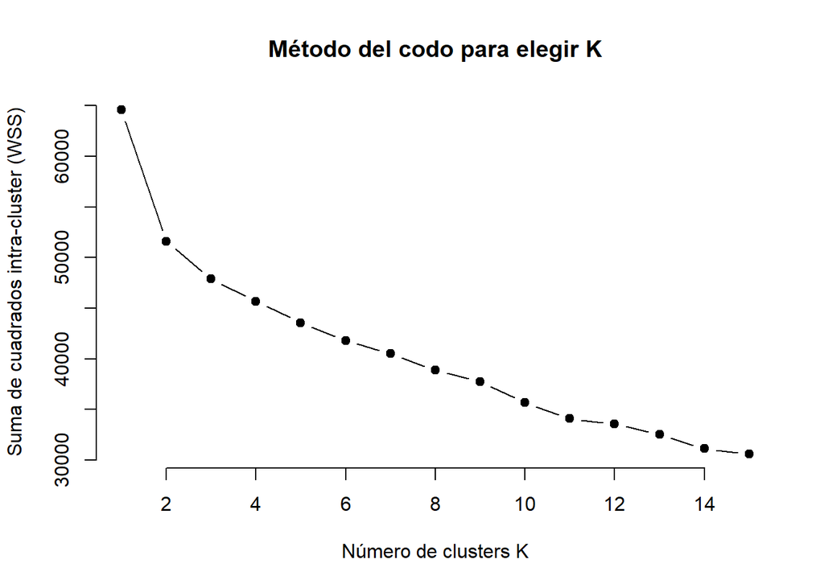

```r
set.seed(123)  # Para reproducibilidad

wss <- numeric(15)  # Vector para guardar suma de cuadrados intra-cluster

for (k in 1:15) {
  km <- kmeans(pca_scores, centers = k, nstart = 25)
  wss[k] <- km$tot.withinss
}

# Graficar método del codo
plot(1:15, wss, type = "b", pch = 19, frame = FALSE,
     xlab = "Número de clusters K",
     ylab = "Suma de cuadrados intra-cluster (WSS)",
     main = "Método del codo para elegir K")
```

```r
k_optimo <- 3

set.seed(123)
kmeans_result <- kmeans(pca_scores, centers = k_optimo, nstart = 25)

# Añadir cluster asignado al dataframe original
df_prepared$cluster <- factor(kmeans_result$cluster)
```

Grafico con los clusters formados:

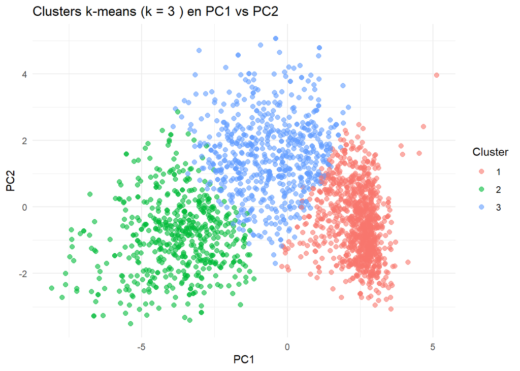

```r
library(ggplot2)

ggplot(data = as.data.frame(pca_scores), aes(x = PC1, y = PC2, color = df_prepared$cluster)) +
  geom_point(alpha = 0.6, size = 2) +
  labs(title = paste("Clusters k-means (k =", k_optimo, ") en PC1 vs PC2"),
       color = "Cluster") +
  theme_minimal()
```

#### Perfilado de cada cluster:

```
## Mostrando variable: income
```

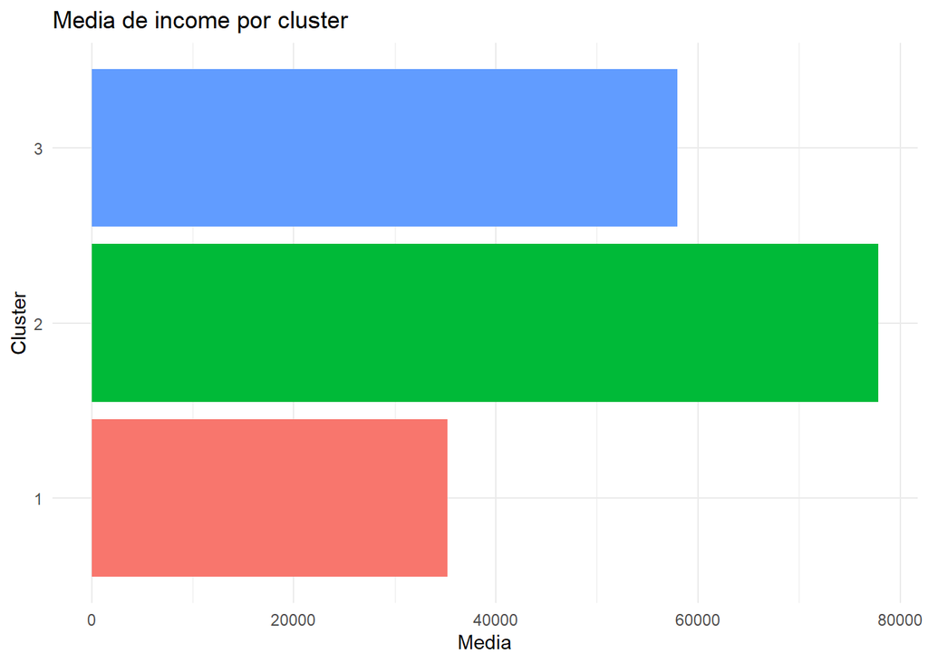

```
## Presiona [Enter] para mostrar la siguiente variable...
## Mostrando variable: kidhome
```

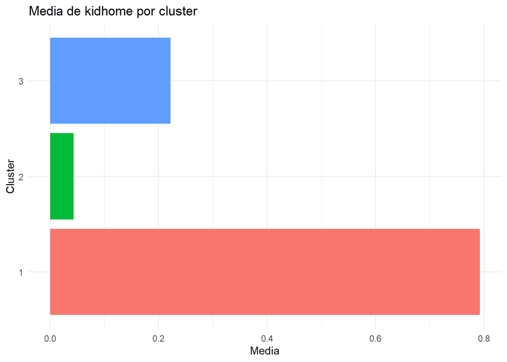

```
## Presiona [Enter] para mostrar la siguiente variable...
## Mostrando variable: teenhome
```

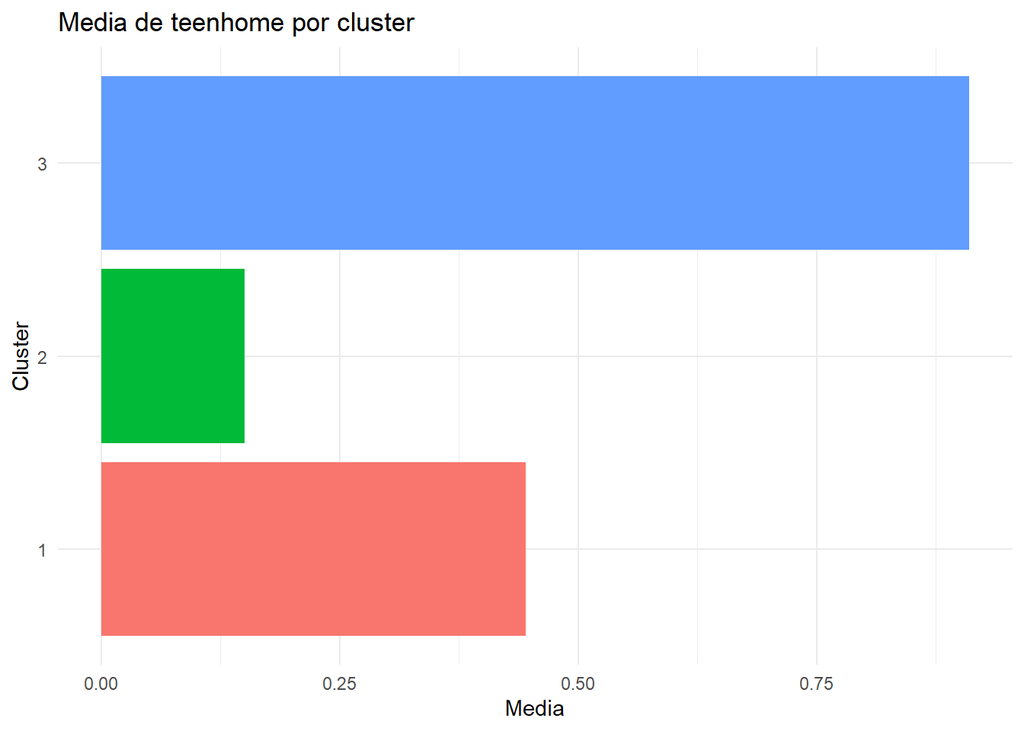

```
## Presiona [Enter] para mostrar la siguiente variable...
## Mostrando variable: recency
```

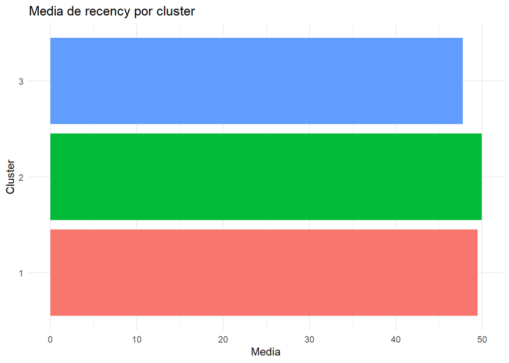

```
## Presiona [Enter] para mostrar la siguiente variable...
## Mostrando variable: customer_age_days
```

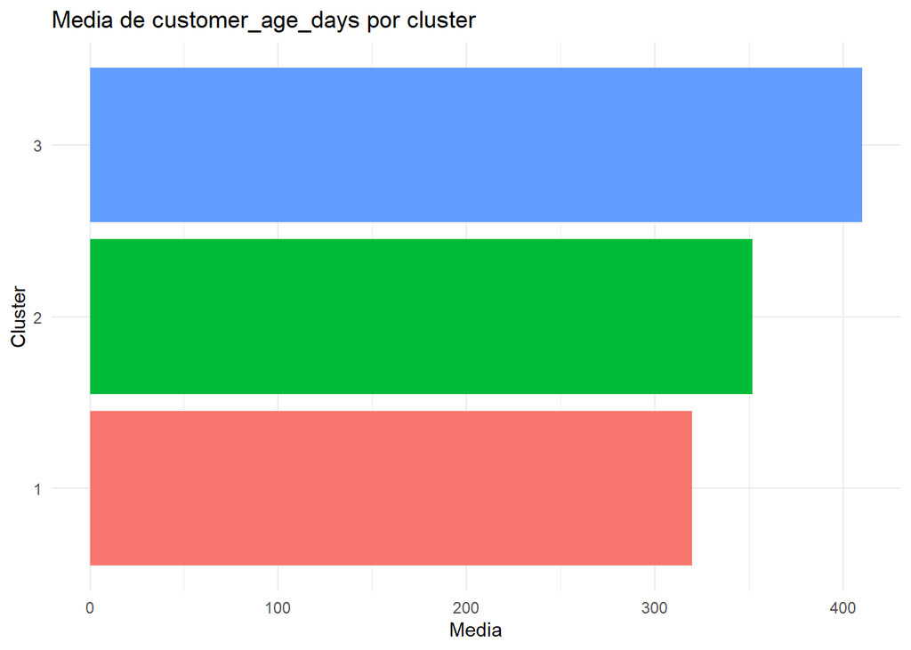

```
## Presiona [Enter] para mostrar la siguiente variable...
## Mostrando variable: mnt_wines
```

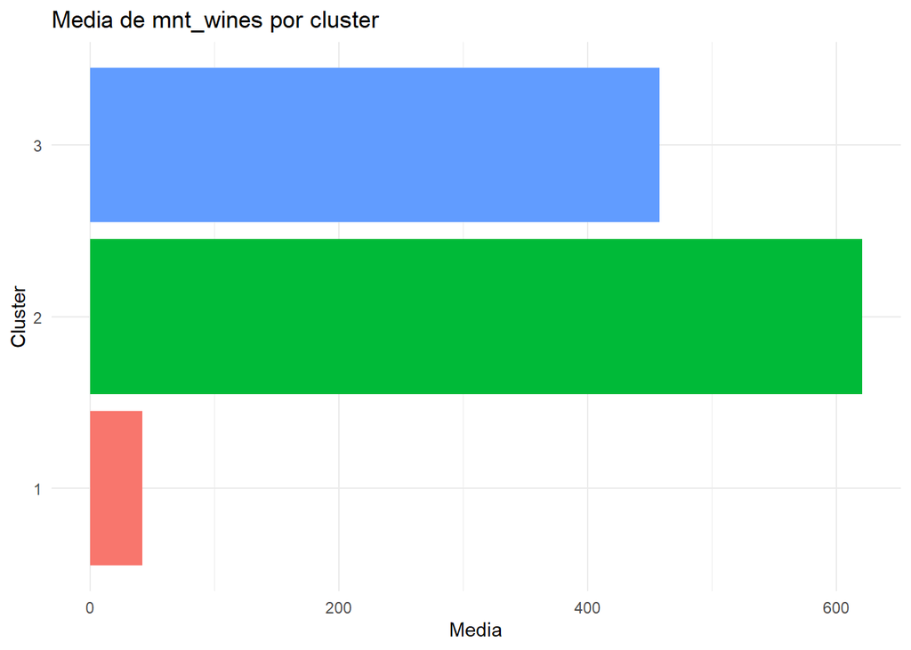

```
## Presiona [Enter] para mostrar la siguiente variable...
## Mostrando variable: mnt_fruits
```

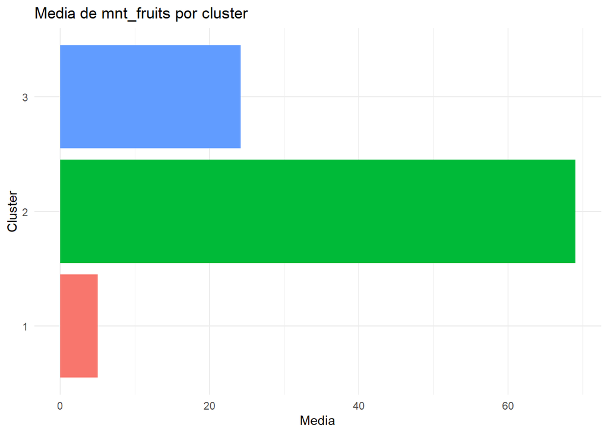

```
## Presiona [Enter] para mostrar la siguiente variable...
## Mostrando variable: mnt_meat_products
```

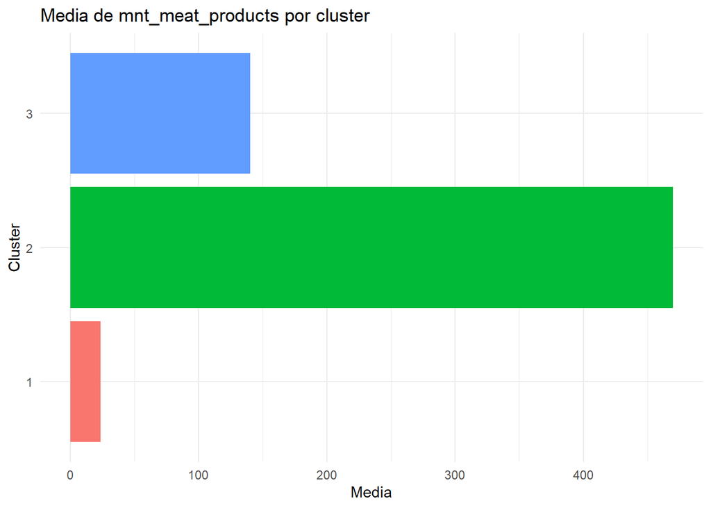

```
## Presiona [Enter] para mostrar la siguiente variable...
## Mostrando variable: mnt_fish_products
```

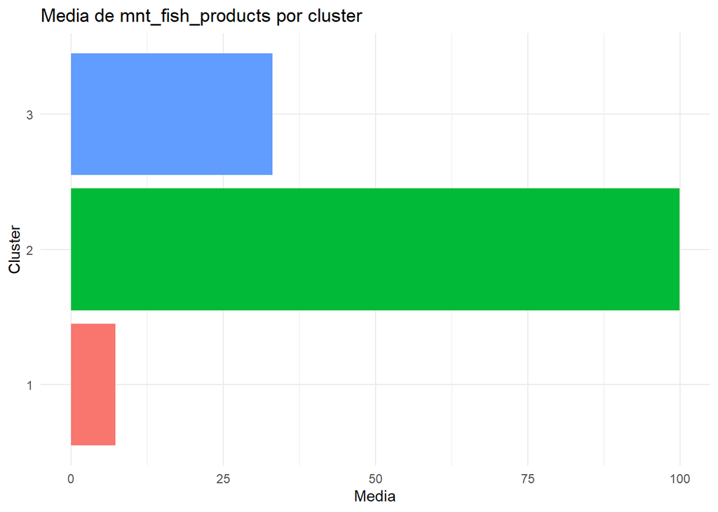

```
## Presiona [Enter] para mostrar la siguiente variable...
## Mostrando variable: mnt_sweet_products
```

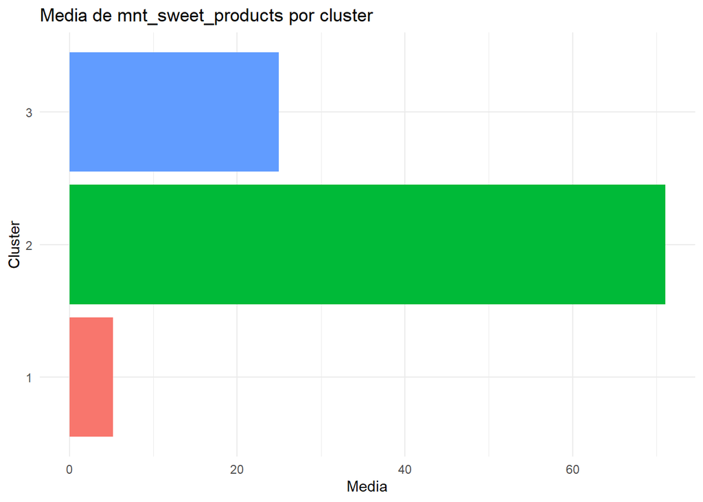

```
## Presiona [Enter] para mostrar la siguiente variable...
## Mostrando variable: mnt_gold_prods
```

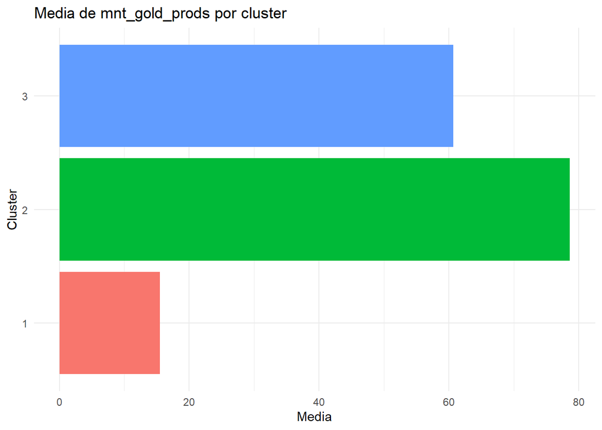

```
## Presiona [Enter] para mostrar la siguiente variable...
## Mostrando variable: num_deals_purchases
```

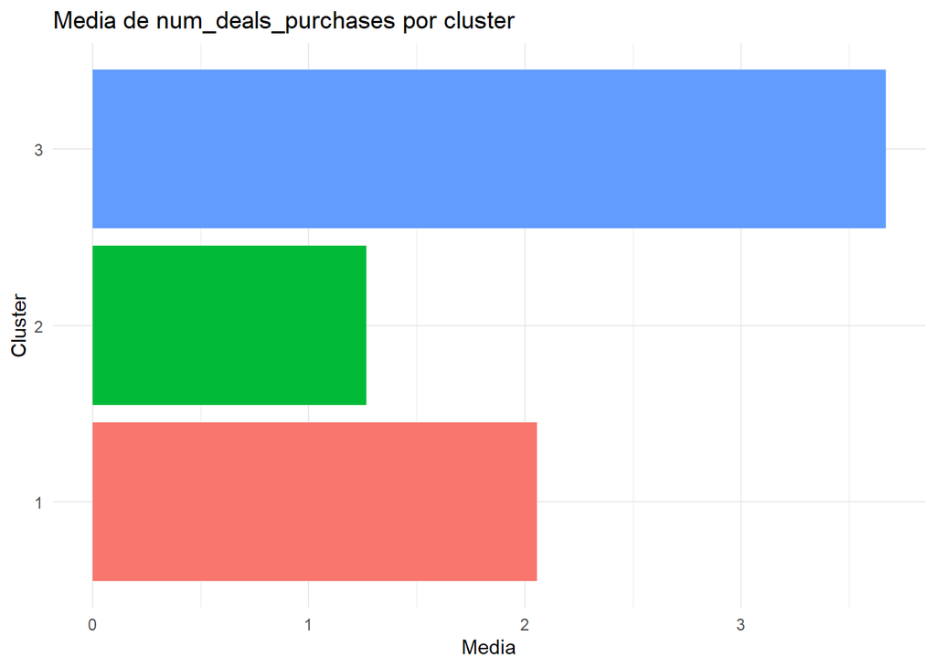

```
## Presiona [Enter] para mostrar la siguiente variable...
## Mostrando variable: num_web_purchases
```

[23 more figures not shown]

```
## Presiona [Enter] para mostrar la siguiente variable...
```

```r
library(dplyr)
library(tidyr)
library(ggplot2)

vars_incluir <- c(
  "income", "kidhome", "teenhome", "recency", "customer_age_days",
  "mnt_wines", "mnt_fruits", "mnt_meat_products", "mnt_fish_products",
  "mnt_sweet_products", "mnt_gold_prods",
  "num_deals_purchases", "num_web_purchases", "num_catalog_purchases",
  "num_store_purchases", "num_web_visits_month",
  "accepted_cmp3", "accepted_cmp4", "accepted_cmp5",
  "accepted_cmp1", "accepted_cmp2", "complain", "z_cost_contact", "z_revenue",
  "educationBasic", "educationGraduation",
  "educationMaster", "educationPhD",
  "marital_statusAlone", "marital_statusDivorced", "marital_statusMarried",
  "marital_statusSingle", "marital_statusTogether", "marital_statusWidow",
  "marital_statusYOLO"
)

df_resumen <- df_prepared %>%
  select(all_of(vars_incluir), cluster) %>%
  group_by(cluster) %>%
  summarise(across(
    everything(),
    list(
      media = ~mean(.x, na.rm = TRUE),
      mediana = ~median(.x, na.rm = TRUE),
      sd = ~sd(.x, na.rm = TRUE),
      min = ~min(.x, na.rm = TRUE),
      max = ~max(.x, na.rm = TRUE)
    ),
    .names = "{col}_{fn}"
  )) %>%
  ungroup()

df_medias <- df_resumen %>%
  select(cluster, ends_with("_media"))

df_long <- df_medias %>%
  pivot_longer(-cluster, names_to = "variable", values_to = "media") %>%
  mutate(variable = gsub("_media", "", variable))

variables <- unique(df_long$variable)

for (var in variables) {
  cat("Mostrando variable:", var, "\n")

  df_plot <- df_long %>% filter(variable == var)

  p <- ggplot(df_plot, aes(x = media, y = cluster, fill = cluster)) +
    geom_col(show.legend = FALSE) +
    labs(title = paste("Media de", var, "por cluster"),
         x = "Media",
         y = "Cluster") +
    theme_minimal()

  print(p)

  readline(prompt = "Presiona [Enter] para mostrar la siguiente variable...")
}
```